# 02_modelFitting_globalTreeModel

## Inital Model Diagnostics

Identifying the optimal threshold based on the prevalence in the training data. ROC Curves based on classification accuracy of the model when used on the testing set (held-out years 2003, 2012 and 2019)

For the bestLambda model:

```r
library(PresenceAbsence)
DATA <- fullModOut$modelPredictions[,c("obs", "pred_opt")] # only training data
DATA$ID <- 1:nrow(DATA)
#pred.prev <- predicted.prevalence(DATA = DATA[,c("ID", "TotalTreeCover_binom", "TotalTreeCover_binom_pred")], threshold = 20)
#accu <- presence.absence.accuracy(DATA[,c("ID", "TotalTreeCover_binom", "TotalTreeCover_binom_pred")], threshold = 20)
optimalThresholds <- optimal.thresholds(DATA = DATA[,c("ID", "obs", "pred_opt")],
                                        threshold = 200, obs.prev = mean(DATA[,"obs"])) # tests 100 thresholds)
rm(DATA)
best_threshold_bestLambda <- optimalThresholds[optimalThresholds$Method == thresholdMethod, 2]
cat(paste0("Optimal threshold for best lambda model based on ROC curve, based on the ",thresholdMethod, " method: ", best_threshold_bestLambda, "\n"))
```

```
## Optimal threshold for best lambda model based on ROC curve, based on the PredPrev=Obs method: 0.683417085427136
```

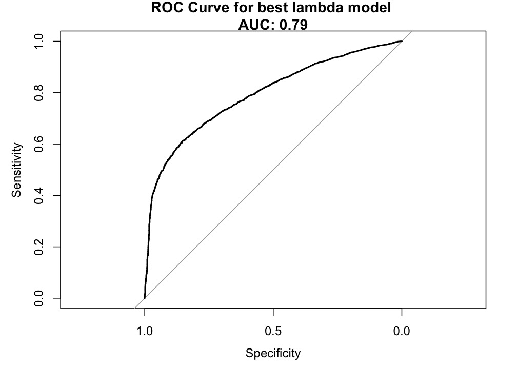

```r
# Now make an ROC curve based on the test set
roc_curve <- roc(pred_glm1_test$TotalTreeCover_binom, pred_glm1_test$TotalTreeCover_binom_pred)
# Plot ROC curve
plot(roc_curve, main =  paste0("ROC Curve for best lambda model \n","AUC: ",round(roc_curve$auc,2)))
```

For the second-bestLambda model:

```r
# best_threshold_secondBest <- coords$threshold
DATA <- fullModOut$modelPredictions[,c("obs", trainDatPredName)]
DATA$ID <- 1:nrow(DATA)
#pred.prev <- predicted.prevalence(DATA = DATA[,c("ID", "TotalTreeCover_binom", "TotalTreeCover_binom_pred")], threshold = 20)
#accu <- presence.absence.accuracy(DATA[,c("ID", "TotalTreeCover_binom", "TotalTreeCover_binom_pred")], threshold = 20)
optimalThresholds <- optimal.thresholds(DATA = DATA[,c("ID", "obs", trainDatPredName)],
                                        threshold = 200, obs.prev = mean(DATA[,"obs"])) # tests 100 thresholds)
rm(DATA)
best_threshold_secondBest <- optimalThresholds[optimalThresholds$Method == thresholdMethod, 2]
cat(paste0("Optimal threshold for second-best lambda model based on ROC curve, based on the ",thresholdMethod, " method: ", best_threshold_secondBest, "\n"))
```

```
## Optimal threshold for second-best lambda model based on ROC curve, based on the PredPrev=Obs method: 0.698492462311558
```

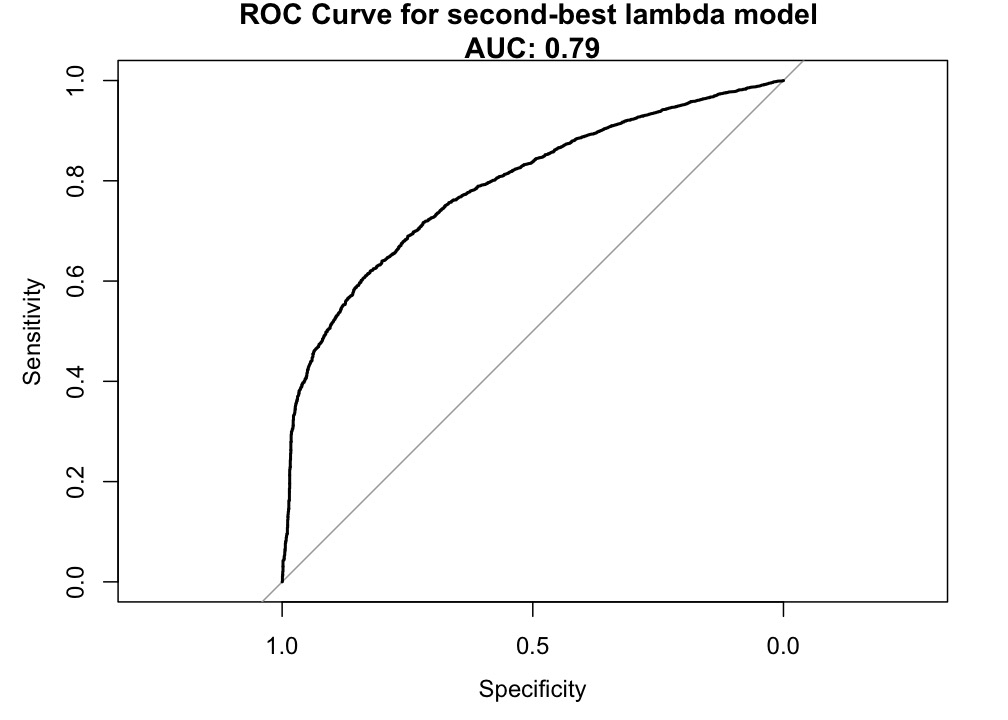

```r
# Now make an ROC curve based on the test set
roc_curve_secondBest <- roc(pred_glm1_1se_test$TotalTreeCover_binom, pred_glm1_1se_test$TotalTreeCover_binom_pred, smooth = FALSE)
# Plot ROC curve
plot(roc_curve_secondBest, main =  paste0("ROC Curve for second-best lambda model \n","AUC: ",round(roc_curve_secondBest$auc,2)))
```

## Use the identified thresholds to make predictions binary

```r
## for test dataset
# best lambda model
# "binomialize" the continuous predictions
pred_glm1_test <- pred_glm1_test %>%
  mutate(TotalTreeCover_binom_pred_binary = TotalTreeCover_binom_pred,
    TotalTreeCover_binom_pred_binary = replace(TotalTreeCover_binom_pred_binary, TotalTreeCover_binom_pred_binary > best_threshold_bestLambda, 1),
         TotalTreeCover_binom_pred_binary = replace(TotalTreeCover_binom_pred_binary, TotalTreeCover_binom_pred_binary <= best_threshold_bestLambda, 0))

# second-best lambda model
# "binomialize" the continuouse predictions
pred_glm1_1se_test <- pred_glm1_1se_test %>%
  mutate(TotalTreeCover_binom_pred_binary = TotalTreeCover_binom_pred,
    TotalTreeCover_binom_pred_binary = replace(TotalTreeCover_binom_pred_binary, TotalTreeCover_binom_pred_binary > best_threshold_secondBest, 1),
         TotalTreeCover_binom_pred_binary = replace(TotalTreeCover_binom_pred_binary, TotalTreeCover_binom_pred_binary <= best_threshold_secondBest, 0))

## for full dataset
# best lambda model
# "binomialize" the continuous predictions
pred_glm1_full <- pred_glm1_full %>%
  mutate(TotalTreeCover_binom_pred_binary = TotalTreeCover_binom_pred,
    TotalTreeCover_binom_pred_binary = replace(TotalTreeCover_binom_pred_binary, TotalTreeCover_binom_pred_binary > best_threshold_bestLambda, 1),
         TotalTreeCover_binom_pred_binary = replace(TotalTreeCover_binom_pred_binary, TotalTreeCover_binom_pred_binary <= best_threshold_bestLambda, 0))

# second-best lambda model
# "binomialize" the continuouse predictions
pred_glm1_1se_full <- pred_glm1_1se_full %>%
  mutate(TotalTreeCover_binom_pred_binary = TotalTreeCover_binom_pred,
    TotalTreeCover_binom_pred_binary = replace(TotalTreeCover_binom_pred_binary, TotalTreeCover_binom_pred_binary > best_threshold_secondBest, 1),
         TotalTreeCover_binom_pred_binary = replace(TotalTreeCover_binom_pred_binary, TotalTreeCover_binom_pred_binary <= best_threshold_secondBest, 0))
```

### Identify Misclassifications

```r
# true positive = tree (1)
# false positive = model says tree, data says no-tree (2)
# true negative = no tree (3)
# false negative = model says no tree, data says tree (4)

# best lambda model - test dataset
pred_glm1_test$missClass <- NA
pred_glm1_test[pred_glm1_test$TotalTreeCover_binom == 1 &
                 pred_glm1_test$TotalTreeCover_binom_pred_binary == 1, "missClass"] <- 1
pred_glm1_test[pred_glm1_test$TotalTreeCover_binom == 0 &
                 pred_glm1_test$TotalTreeCover_binom_pred_binary == 0, "missClass"] <- 3
pred_glm1_test[pred_glm1_test$TotalTreeCover_binom == 0 &
                 pred_glm1_test$TotalTreeCover_binom_pred_binary == 1, "missClass"] <- 2
pred_glm1_test[pred_glm1_test$TotalTreeCover_binom == 1 &
                 pred_glm1_test$TotalTreeCover_binom_pred_binary == 0, "missClass"] <- 4

# best lambda model - full dataset
pred_glm1_full$missClass <- NA
pred_glm1_full[pred_glm1_full$TotalTreeCover_binom == 1 &
                 pred_glm1_full$TotalTreeCover_binom_pred_binary == 1, "missClass"] <- 1
pred_glm1_full[pred_glm1_full$TotalTreeCover_binom == 0 &
                 pred_glm1_full$TotalTreeCover_binom_pred_binary == 0, "missClass"] <- 3
pred_glm1_full[pred_glm1_full$TotalTreeCover_binom == 0 &
                 pred_glm1_full$TotalTreeCover_binom_pred_binary == 1, "missClass"] <- 2
pred_glm1_full[pred_glm1_full$TotalTreeCover_binom == 1 &
                 pred_glm1_full$TotalTreeCover_binom_pred_binary == 0, "missClass"] <- 4

# second-best lambda model - test dataset
pred_glm1_1se_test$missClass <- NA
pred_glm1_1se_test[pred_glm1_1se_test$TotalTreeCover_binom == 1 &
                 pred_glm1_1se_test$TotalTreeCover_binom_pred_binary == 1, "missClass"] <- 1
pred_glm1_1se_test[pred_glm1_1se_test$TotalTreeCover_binom == 0 &
                 pred_glm1_1se_test$TotalTreeCover_binom_pred_binary == 0, "missClass"] <- 3
pred_glm1_1se_test[pred_glm1_1se_test$TotalTreeCover_binom == 0 &
                 pred_glm1_1se_test$TotalTreeCover_binom_pred_binary == 1, "missClass"] <- 2
pred_glm1_1se_test[pred_glm1_1se_test$TotalTreeCover_binom == 1 &
                 pred_glm1_1se_test$TotalTreeCover_binom_pred_binary == 0, "missClass"] <- 4

# second-best lambda model - full dataset
pred_glm1_1se_full$missClass <- NA
pred_glm1_1se_full[pred_glm1_1se_full$TotalTreeCover_binom == 1 &
                 pred_glm1_1se_full$TotalTreeCover_binom_pred_binary == 1, "missClass"] <- 1
pred_glm1_1se_full[pred_glm1_1se_full$TotalTreeCover_binom == 0 &
                 pred_glm1_1se_full$TotalTreeCover_binom_pred_binary == 0, "missClass"] <- 3
pred_glm1_1se_full[pred_glm1_1se_full$TotalTreeCover_binom == 0 &
                 pred_glm1_1se_full$TotalTreeCover_binom_pred_binary == 1, "missClass"] <- 2
pred_glm1_1se_full[pred_glm1_1se_full$TotalTreeCover_binom == 1 &
                 pred_glm1_1se_full$TotalTreeCover_binom_pred_binary == 0, "missClass"] <- 4
```

## Maps of Observations, Predictions, and Residuals

### Observations - continuous and binary total tree cover for the full dataset

```r
# rasterize
# get reference raster
# use the gridMet raster
test_rast_dayMet <- rast("../../../Data_raw/dayMet/rawMonthlyData/orders/70e0da02b9d2d6e8faa8c97d211f3546/Daymet_Monthly_V4R1/data/daymet_v4_prcp_monttl_na_1980.tif") %>%
  #terra::project(terra::crs("EPSG:4326")) %>%
  terra::crop(ext(-2000000, 2600000, -1900000, 1500000))

## aggregate to a 4x4km^2 grid
test_rast <- test_rast_dayMet %>%
  terra::aggregate(fact = 8, fun = "mean")
# test_rast_Untranfsormed <-  rast("../../../Data_raw/gridMet/pr_2020.nc") #%>% ## mean cell size of unaggregated grid size (16709380m^2)
# test_rast <- test_rast_Untranfsormed %>%
#    terra::aggregate(fact = 2, fun = "mean") #%>%
regions <- sf::st_read(dsn = "../../../Data_raw/Level2Ecoregions/", layer = "NA_CEC_Eco_Level2")
```

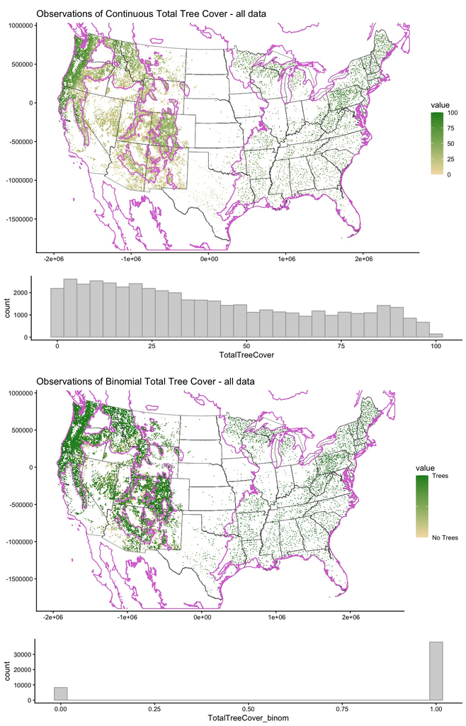

```r
regions <- regions %>%
  st_transform(crs = st_crs(crs(test_rast))) %>%
  st_make_valid()

ecoregionLU <- data.frame("NA_L1NAME" = sort(unique(regions$NA_L1NAME)),
                        "newRegion" = c(NA, "Forest", "dryShrubGrass",
                                        "dryShrubGrass", "Forest", "dryShrubGrass",
                                       "dryShrubGrass", "Forest", "Forest",
                                       "dryShrubGrass", "Forest", "Forest",
                                       "Forest", "Forest", "dryShrubGrass",
                                       NA
                                        ))
goodRegions <- regions %>%
  left_join(ecoregionLU)
mapRegions <- goodRegions %>%
  filter(!is.na(newRegion)) %>%
  group_by(newRegion) %>%
  summarise(geometry = sf::st_union(geometry)) %>%
  ungroup() %>%
  st_simplify(dTolerance = 1000) %>%
  sf::st_crop(c("xmin" = -2000000, "xmax" = 2600000, "ymin" = -1900000, "ymax" = 1500000))
# make shapefile of cropped state boundaries in appropriate crs
cropped_states_2 <- cropped_states %>%
  st_transform(crs = crs(test_rast)) %>%
  st_make_valid()  %>%
  sf::st_crop(c("xmin" = -2000000, "xmax" = 2600000, "ymin" = -1900000, "ymax" = 1500000))

# function for getting the statistical mode
Mode <- function(x, ...) {
  ux <- unique(x)
  ux[which.max(tabulate(match(x, ux)))]
}

# make a multi-layer raster w/ layers for each variable of interest
pred_glm1_full_sf <- pred_glm1_full %>%
  st_as_sf(coords = c("x", "y"), crs = crs("EPSG:4326")) %>%
  st_transform(crs(test_rast)) %>%
  terra::vect()
testRast2 <- lapply(c("TotalTreeCover", "TotalTreeCover_binom", "TotalTreeCover_binom_pred", "TotalTreeCover_binom_pred_binary", "resid", "missClass"), FUN = function(x) {
  # S4 method for class 'data.frame'
  if (x %in% c("TotalTreeCover", "TotalTreeCover_binom", "TotalTreeCover_binom_pred", "TotalTreeCover_binom_pred_binary", "resid")) {
    temp <- terra::rasterize(x = pred_glm1_full_sf, y = test_rast,
                         field = x, fun = mean, na.rm = TRUE)
    names(temp) <- x
  } else {
    temp <- terra::rasterize(x = pred_glm1_full_sf, y = test_rast,
                         field = x, fun = Mode, na.rm = TRUE)
    # get the % aggreement between values in the dayMetx8 cell
    temp2 <- terra::rasterize(x = pred_glm1_full_sf, y = test_rast$daymet_v4_prcp_monttl_na_1980_1,
                         field = x, fun = function(y) {
                           yTemp <- y[!is.na(y)]
                           yMode <- Mode(yTemp)
                           (sum(yTemp == yMode)/length(yTemp))*100
                         })
    temp <- c(as.factor(temp$missClass), temp2)
    names(temp) <- c("missClass", "PercAgreement")
  }

 return(temp)
  }
)
pred_glm1_full_RAST <- c(testRast2[[1]], testRast2[[2]], testRast2[[3]], testRast2[[4]], testRast2[[5]], testRast2[[6]])

# ## compare
# par(mfrow = c(2,1))
# terra::plot(pred_glm1_full_RAST$TotalTreeCover,  maxcell = 30000000, main = "gridMet")
# terra::plot(pred_glm1_full_RAST_dayMet$TotalTreeCover, maxcell = 30000000, main = "dayMet")
# par(mfrow = c(1,1))
##
# make figure of raw tree cover
map_obs_cont <- ggplot() +
geom_spatraster(data = pred_glm1_full_RAST, aes(fill = TotalTreeCover), maxcell = 50000000) +
 #geom_sf(data = pred_glm1_full_RAST, aes(col = TotalTreeCover)) +
  # stat_summary_2d(data = plotObs, aes(x = x, y = y, z = TotalTreeCover), fun = mean, binwidth = .05) +
  geom_sf(data=cropped_states_2 ,fill=NA ) +
  geom_sf(data = mapRegions, fill = NA, col = "orchid", lwd = .5) +
labs(title = paste0("Observations of Continuous Total Tree Cover - all data")) +
  scale_fill_gradient2(low = "brown",
                       mid = "wheat" ,
                       high = "forestgreen" ,
                       midpoint = 0,   na.value = "white") +
  coord_sf(datum = st_crs(pred_glm1_full_RAST)) +
   # xlim(-104, -100) +
   # ylim(30, 33)
  xlim(-2000000, 2500000) +
  ylim(-1800000, 900000)

# make figure of binomialized tree cover
map_obs <- ggplot() +
geom_spatraster(data = pred_glm1_full_RAST, aes(fill = TotalTreeCover_binom), maxcell = 50000000) +
 #geom_sf(data = plotObs, aes(col = TotalTreeCover_binom)) +
   #stat_summary_2d(data = plotObs, aes(x = x, y = y, z = TotalTreeCover_binom), fun = mean, binwidth = .05) +
     scale_fill_viridis_c(option = "A", guide = guide_colorbar(title = "% cover"),
                          limits = c(0,100))  +
  geom_sf(data=cropped_states_2 ,fill=NA ) +
  geom_sf(data = mapRegions, fill = NA, col = "orchid", lwd = .5) +
labs(title = paste0("Observations of Binomial Total Tree Cover - all data")) +
  scale_fill_continuous(breaks =  c(0, 0.5, 1), palette = c("wheat", "forestgreen"),
                    labels = c("No Trees",
                               "",
                      "Trees"), na.value = "white") +
  coord_sf(datum = st_crs(pred_glm1_full_RAST)) +
  xlim(-2000000, 2500000) +
  ylim(-1800000, 900000)

hist_obs_cont <- pred_glm1_full %>%
  ggplot() +
  geom_histogram(aes(TotalTreeCover), fill = "lightgrey", col = "darkgrey")

hist_obs <- pred_glm1_full%>%
  ggplot() +
  geom_histogram(aes(TotalTreeCover_binom), fill = "lightgrey", col = "darkgrey")

library(ggpubr)
ggarrange(map_obs_cont, hist_obs_cont, map_obs, hist_obs, heights = c(3, 1, 3, 1), ncol = 1)
```

### Observations - continuous and binary total tree cover for the test dataset

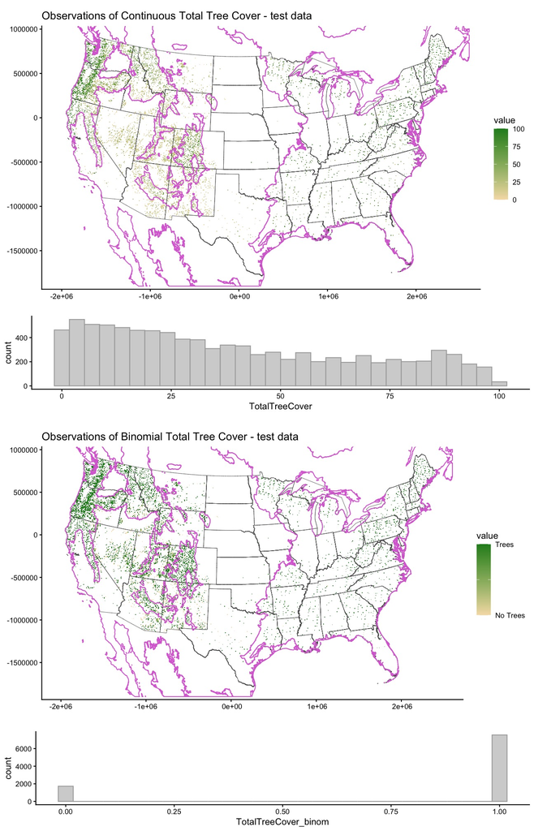

```r
pred_glm1_test_sf <- pred_glm1_test %>%
  st_as_sf(coords = c("x", "y"), crs = crs("EPSG:4326")) %>%
  st_transform(crs(test_rast)) %>%
  terra::vect()
# make raster of test set
# make a multi-layer raster w/ layers for each variable of interest
testRast_test <- lapply(c("TotalTreeCover", "TotalTreeCover_binom", "TotalTreeCover_binom_pred", "TotalTreeCover_binom_pred_binary", "resid", "missClass"), FUN = function(x) {
  # S4 method for class 'data.frame'
  if (x %in% c("TotalTreeCover", "TotalTreeCover_binom", "TotalTreeCover_binom_pred", "TotalTreeCover_binom_pred_binary", "resid")) {
    temp <- terra::rasterize(x = pred_glm1_test_sf, y = test_rast,
                         field = x, fun = mean, na.rm = TRUE)
    names(temp) <- x
  } else {
    temp <- terra::rasterize(x = pred_glm1_test_sf, y = test_rast,
                         field = x, fun = Mode, na.rm = TRUE)
    # get the % aggreement between values in the dayMetx8 cell
    temp2 <- terra::rasterize(x = pred_glm1_test_sf, y = test_rast$daymet_v4_prcp_monttl_na_1980_1,
                         field = x, fun = function(y) {
                           yTemp <- y[!is.na(y)]
                           yMode <- Mode(yTemp)
                           (sum(yTemp == yMode)/length(yTemp))*100
                         })
    temp <- c(as.factor(temp$missClass), temp2)
    names(temp) <- c("missClass", "PercAgreement")
  }

 return(temp)
  }
)
pred_glm1_test_RAST <- c(testRast_test[[1]], testRast_test[[2]], testRast_test[[3]], testRast_test[[4]], testRast_test[[5]], testRast_test[[6]])

# make maps
map_obs_cont_test <- ggplot() +
geom_spatraster(data = pred_glm1_test_RAST, aes(fill = TotalTreeCover), maxcell = 50000000) +
 #geom_sf(data = pred_glm1_full_RAST, aes(col = TotalTreeCover)) +
  # stat_summary_2d(data = plotObs, aes(x = x, y = y, z = TotalTreeCover), fun = mean, binwidth = .05) +
  geom_sf(data=cropped_states_2 ,fill=NA ) +
  geom_sf(data = mapRegions, fill = NA, col = "orchid", lwd = .5) +
labs(title = paste0("Observations of Continuous Total Tree Cover - test data")) +
  scale_fill_gradient2(low = "brown",
                       mid = "wheat" ,
                       high = "forestgreen" ,
                       midpoint = 0,   na.value = "white") +
  coord_sf(datum = st_crs(pred_glm1_full_RAST)) +
   # xlim(-104, -100) +
   # ylim(30, 33)
  xlim(-2000000, 2500000) +
  ylim(-1800000, 900000)

# make figure of binomialized tree cover
map_obs_test <- ggplot() +
geom_spatraster(data = pred_glm1_test_RAST, aes(fill = TotalTreeCover_binom), maxcell = 50000000) +
 #geom_sf(data = plotObs, aes(col = TotalTreeCover_binom)) +
   #stat_summary_2d(data = plotObs, aes(x = x, y = y, z = TotalTreeCover_binom), fun = mean, binwidth = .05) +
     scale_fill_viridis_c(option = "A", guide = guide_colorbar(title = "% cover"),
                          limits = c(0,100))  +
  geom_sf(data=cropped_states_2 ,fill=NA ) +
  geom_sf(data = mapRegions, fill = NA, col = "orchid", lwd = .5) +
labs(title = paste0("Observations of Binomial Total Tree Cover - test data")) +
  scale_fill_continuous(breaks =  c(0, 0.5, 1), palette = c("wheat", "forestgreen"),
                    labels = c("No Trees",
                               "",
                      "Trees"), na.value = "white") +
  coord_sf(datum = st_crs(pred_glm1_full_RAST)) +
  xlim(-2000000, 2500000) +
  ylim(-1800000, 900000)

hist_obs_cont_test <- pred_glm1_test %>%
  ggplot() +
  geom_histogram(aes(TotalTreeCover), fill = "lightgrey", col = "darkgrey")

  hist_obs_test <- pred_glm1_test%>%
  ggplot() +
  geom_histogram(aes(TotalTreeCover_binom), fill = "lightgrey", col = "darkgrey")

ggarrange(map_obs_cont_test, hist_obs_cont_test, map_obs_test, hist_obs_test, heights = c(3, 1, 3, 1), ncol = 1)
```

### Predictions on the full and test dataset using the *best lambda* model

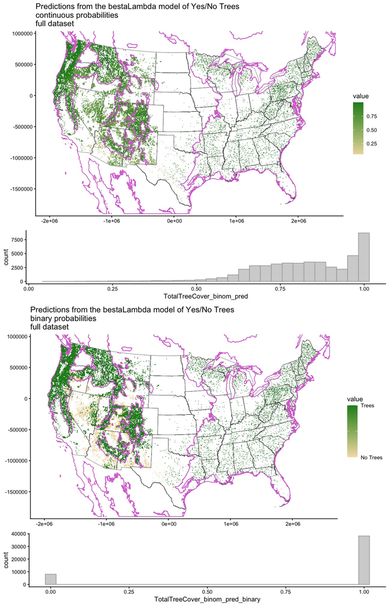

```r
# make figures of predictions w/ the full dataset
map_preds1_cont <- ggplot() +
geom_spatraster(data = pred_glm1_full_RAST, aes(fill = TotalTreeCover_binom_pred), maxcell = 20000000) +
 #geom_sf(data = plotObs_rast2, aes(col = TotalTreeCover)) +
  # stat_summary_2d(data = plotObs, aes(x = x, y = y, z = TotalTreeCover), fun = mean, binwidth = .05) +
  geom_sf(data=cropped_states_2 ,fill=NA ) +
  geom_sf(data = mapRegions, fill = NA, col = "orchid", lwd = .5) +
labs(title = paste0("Predictions from the bestaLambda model of Yes/No Trees \ncontinuous probabilities \nfull dataset")) +
  scale_fill_gradient2(low = "brown",
                       mid = "wheat" ,
                       high = "forestgreen" ,
                       midpoint = 0,   na.value = "white") +
  coord_sf(datum = st_crs(pred_glm1_full_RAST)) +
  xlim(-2000000, 2500000) +
  ylim(-1800000, 900000)

# make figure of binomialized tree cover
map_preds1 <- ggplot() +
geom_spatraster(data = pred_glm1_full_RAST, aes(fill = TotalTreeCover_binom_pred_binary), maxcell = 20000000) +
 #geom_sf(data = plotObs, aes(col = TotalTreeCover_binom)) +
   #stat_summary_2d(data = plotObs, aes(x = x, y = y, z = TotalTreeCover_binom), fun = mean, binwidth = .05) +
     scale_fill_viridis_c(option = "A", guide = guide_colorbar(title = "% cover"),
                          limits = c(0,100))  +
  geom_sf(data=cropped_states_2 ,fill=NA ) +
  geom_sf(data = mapRegions, fill = NA, col = "orchid", lwd = .5) +
labs(title = paste0("Predictions from the bestaLambda model of Yes/No Trees \nbinary probabilities \nfull dataset")) +
  scale_fill_continuous(breaks =  c(0, 0.5, 1), palette = c("wheat", "forestgreen"),
                    labels = c("No Trees",
                               "",
                      "Trees"), na.value = "white") +
  coord_sf(datum = st_crs(pred_glm1_full_RAST)) +
  xlim(-2000000, 2500000) +
  ylim(-1800000, 900000)

hist_preds1_cont <- pred_glm1_full %>%
  ggplot() +
  geom_histogram(aes(TotalTreeCover_binom_pred), fill = "lightgrey", col = "darkgrey")

hist_preds1 <- pred_glm1_full%>%
  ggplot() +
  geom_histogram(aes(TotalTreeCover_binom_pred_binary), fill = "lightgrey", col = "darkgrey")

ggarrange(map_preds1_cont, hist_preds1_cont, map_preds1, hist_preds1, heights = c(3, 1, 3, 1), ncol = 1)
```

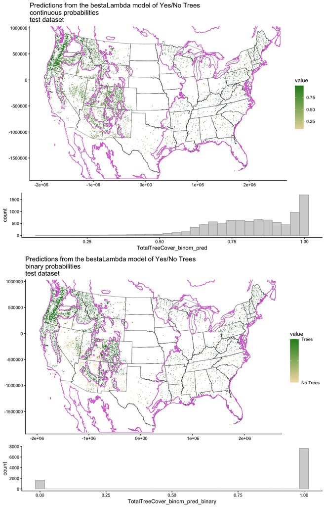

```r
# make figures of predictions w/ the test dataset
map_preds1_cont_test <- ggplot() +
geom_spatraster(data = pred_glm1_test_RAST, aes(fill = TotalTreeCover_binom_pred), maxcell = 20000000) +
 #geom_sf(data = plotObs_rast2, aes(col = TotalTreeCover)) +
  # stat_summary_2d(data = plotObs, aes(x = x, y = y, z = TotalTreeCover), fun = mean, binwidth = .05) +
  geom_sf(data=cropped_states_2 ,fill=NA ) +
  geom_sf(data = mapRegions, fill = NA, col = "orchid", lwd = .5) +
labs(title = paste0("Predictions from the bestaLambda model of Yes/No Trees \ncontinuous probabilities \ntest dataset")) +
  scale_fill_gradient2(low = "brown",
                       mid = "wheat" ,
                       high = "forestgreen" ,
                       midpoint = 0,   na.value = "white") +
  coord_sf(datum = st_crs(pred_glm1_full_RAST)) +
  xlim(-2000000, 2500000) +
  ylim(-1800000, 900000)

# make figure of binomialized tree cover
map_preds1_test <- ggplot() +
geom_spatraster(data = pred_glm1_test_RAST, aes(fill = TotalTreeCover_binom_pred_binary), maxcell = 20000000) +
 #geom_sf(data = plotObs, aes(col = TotalTreeCover_binom)) +
   #stat_summary_2d(data = plotObs, aes(x = x, y = y, z = TotalTreeCover_binom), fun = mean, binwidth = .05) +
     scale_fill_viridis_c(option = "A", guide = guide_colorbar(title = "% cover"),
                          limits = c(0,100))  +
  geom_sf(data=cropped_states_2 ,fill=NA ) +
  geom_sf(data = mapRegions, fill = NA, col = "orchid", lwd = .5) +
labs(title = paste0("Predictions from the bestaLambda model of Yes/No Trees \nbinary probabilities \ntest dataset")) +
  scale_fill_continuous(breaks =  c(0, 0.5, 1), palette = c("wheat", "forestgreen"),
                    labels = c("No Trees",
                               "",
                      "Trees"), na.value = "white") +
  coord_sf(datum = st_crs(pred_glm1_full_RAST)) +
  xlim(-2000000, 2500000) +
  ylim(-1800000, 900000)

hist_preds1_cont_test <- pred_glm1_test %>%
  ggplot() +
  geom_histogram(aes(TotalTreeCover_binom_pred), fill = "lightgrey", col = "darkgrey")

hist_preds1_test <- pred_glm1_test%>%
  ggplot() +
  geom_histogram(aes(TotalTreeCover_binom_pred_binary), fill = "lightgrey", col = "darkgrey")

ggarrange(map_preds1_cont_test, hist_preds1_cont_test, map_preds1_test, hist_preds1_test, heights = c(3, 1, 3, 1), ncol = 1)
```

### Predictions on the full and test datasets using the *second best lambda* model

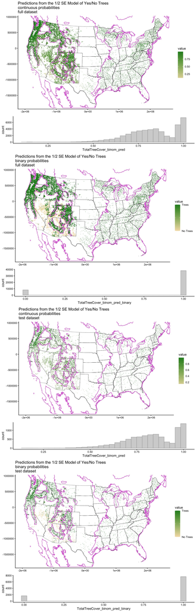

```r
if ( name_secondBestMod == "Intercept_Only") {
  print("The next best lambda model only contains one predictor (an intercept)")
} else {
  pred_glm1_1se_full_sf <- pred_glm1_1se_full %>%
  st_as_sf(coords = c("x", "y"), crs = crs("EPSG:4326")) %>%
  st_transform(crs(test_rast)) %>%
  terra::vect()
  # make a raster of the full dataset
# make a multi-layer raster w/ layers for each variable of interest
testRast3 <- lapply(c("TotalTreeCover", "TotalTreeCover_binom", "TotalTreeCover_binom_pred", "TotalTreeCover_binom_pred_binary", "resid", "missClass"), FUN = function(x) {
  # S4 method for class 'data.frame'
 if (x %in% c("TotalTreeCover", "TotalTreeCover_binom", "TotalTreeCover_binom_pred", "TotalTreeCover_binom_pred_binary", "resid")) {
    temp <- terra::rasterize(x = pred_glm1_1se_full_sf, y = test_rast,
                         field = x, fun = mean, na.rm = TRUE)
    names(temp) <- x
  } else {
    temp <- terra::rasterize(x = pred_glm1_1se_full_sf, y = test_rast,
                         field = x, fun = Mode, na.rm = TRUE)
    # get the % aggreement between values in the dayMetx8 cell
    temp2 <- terra::rasterize(x = pred_glm1_1se_full_sf, y = test_rast$daymet_v4_prcp_monttl_na_1980_1,
                         field = x, fun = function(y) {
                           yTemp <- y[!is.na(y)]
                           yMode <- Mode(yTemp)
                           (sum(yTemp == yMode)/length(yTemp))*100
                         })
    temp <- c(as.factor(temp$missClass), temp2)
    names(temp) <- c("missClass", "PercAgreement")
  }

 return(temp)
  }
)
pred_glm1_1se_full_RAST <- c(testRast3[[1]], testRast3[[2]], testRast3[[3]], testRast3[[4]], testRast3[[5]], testRast3[[6]])

# make raster of test set
 pred_glm1_1se_test_sf <- pred_glm1_1se_test %>%
  st_as_sf(coords = c("x", "y"), crs = crs("EPSG:4326")) %>%
  st_transform(crs(test_rast)) %>%
  terra::vect()
# make a multi-layer raster w/ layers for each variable of interest
testRast_test2 <- lapply(c("TotalTreeCover", "TotalTreeCover_binom", "TotalTreeCover_binom_pred", "TotalTreeCover_binom_pred_binary", "resid", "missClass"), FUN = function(x) {
  # S4 method for class 'data.frame'
 if (x %in% c("TotalTreeCover", "TotalTreeCover_binom", "TotalTreeCover_binom_pred", "TotalTreeCover_binom_pred_binary", "resid")) {
    temp <- terra::rasterize(x = pred_glm1_1se_test_sf, y = test_rast,
                         field = x, fun = mean, na.rm = TRUE)
    names(temp) <- x
  } else {
    temp <- terra::rasterize(x = pred_glm1_1se_test_sf, y = test_rast,
                         field = x, fun = Mode, na.rm = TRUE)
    # get the % aggreement between values in the dayMetx8 cell
    temp2 <- terra::rasterize(x = pred_glm1_1se_test_sf, y = test_rast$daymet_v4_prcp_monttl_na_1980_1,
                         field = x, fun = function(y) {
                           yTemp <- y[!is.na(y)]
                           yMode <- Mode(yTemp)
                           (sum(yTemp == yMode)/length(yTemp))*100
                         })
    temp <- c(as.factor(temp$missClass), temp2)
    names(temp) <- c("missClass", "PercAgreement")
  }

 return(temp)
  }
)
pred_glm1_1se_test_RAST <- c(testRast_test2[[1]], testRast_test2[[2]], testRast_test2[[3]], testRast_test2[[4]], testRast_test2[[5]], testRast_test2[[6]])

# make figures of predictions w/ the full dataset
map_preds2_cont <- ggplot() +
geom_spatraster(data = pred_glm1_1se_full_RAST, aes(fill = TotalTreeCover_binom_pred), maxcell = 20000000) +
 #geom_sf(data = plotObs_rast2, aes(col = TotalTreeCover)) +
  # stat_summary_2d(data = plotObs, aes(x = x, y = y, z = TotalTreeCover), fun = mean, binwidth = .05) +
  geom_sf(data=cropped_states_2 ,fill=NA ) +
  geom_sf(data = mapRegions, fill = NA, col = "orchid", lwd = .5) +
labs(title = paste0("Predictions from the ", name_secondBestMod, " of Yes/No Trees \ncontinuous probabilities \nfull dataset")) +
  scale_fill_gradient2(low = "brown",
                       mid = "wheat" ,
                       high = "forestgreen" ,
                       midpoint = 0,   na.value = "white") +
  coord_sf(datum = st_crs(pred_glm1_full_RAST)) +
  xlim(-2000000, 2500000) +
  ylim(-1800000, 900000)

# make figure of binomialized tree cover
map_preds2 <- ggplot() +
geom_spatraster(data = pred_glm1_1se_full_RAST, aes(fill = TotalTreeCover_binom_pred_binary), maxcell = 20000000) +
 #geom_sf(data = plotObs, aes(col = TotalTreeCover_binom)) +
   #stat_summary_2d(data = plotObs, aes(x = x, y = y, z = TotalTreeCover_binom), fun = mean, binwidth = .05) +
  geom_sf(data=cropped_states_2 ,fill=NA ) +
  geom_sf(data = mapRegions, fill = NA, col = "orchid", lwd = .5) +
labs(title = paste0("Predictions from the ", name_secondBestMod, " of Yes/No Trees \nbinary probabilities \nfull dataset")) +
  scale_fill_continuous(breaks =  c(0, 0.5, 1), palette = c("wheat", "forestgreen"),
                    labels = c("No Trees",
                               "",
                      "Trees"), na.value = "white") +
  coord_sf(datum = st_crs(pred_glm1_full_RAST)) +
  xlim(-2000000, 2500000) +
  ylim(-1800000, 900000)

hist_preds2_cont <- pred_glm1_1se_full %>%
  ggplot() +
  geom_histogram(aes(TotalTreeCover_binom_pred), fill = "lightgrey", col = "darkgrey")

hist_preds2 <- pred_glm1_1se_full%>%
  ggplot() +
  geom_histogram(aes(TotalTreeCover_binom_pred_binary), fill = "lightgrey", col = "darkgrey")


# make figures of predictions w/ the test dataset
map_preds2_cont_test <- ggplot() +
geom_spatraster(data = pred_glm1_1se_test_RAST, aes(fill = TotalTreeCover_binom_pred), maxcell = 20000000) +
 #geom_sf(data = plotObs_rast2, aes(col = TotalTreeCover)) +
  # stat_summary_2d(data = plotObs, aes(x = x, y = y, z = TotalTreeCover), fun = mean, binwidth = .05) +
  geom_sf(data=cropped_states_2 ,fill=NA ) +
  geom_sf(data = mapRegions, fill = NA, col = "orchid", lwd = .5) +
labs(title = paste0("Predictions from the ", name_secondBestMod, " of Yes/No Trees \ncontinuous probabilities \ntest dataset")) +
  scale_fill_gradient2(low = "brown",
                       mid = "wheat" ,
                       high = "forestgreen" ,
                       midpoint = 0,   na.value = "white") +
  coord_sf(datum = st_crs(pred_glm1_full_RAST)) +
  xlim(-2000000, 2500000) +
  ylim(-1800000, 900000)

# make figure of binomialized tree cover
map_preds2_test <- ggplot() +
geom_spatraster(data = pred_glm1_1se_test_RAST, aes(fill = TotalTreeCover_binom_pred_binary), maxcell = 20000000) +
 #geom_sf(data = plotObs, aes(col = TotalTreeCover_binom)) +
   #stat_summary_2d(data = plotObs, aes(x = x, y = y, z = TotalTreeCover_binom), fun = mean, binwidth = .05) +
  geom_sf(data=cropped_states_2 ,fill=NA ) +
  geom_sf(data = mapRegions, fill = NA, col = "orchid", lwd = .5) +
labs(title = paste0("Predictions from the ", name_secondBestMod, " of Yes/No Trees \nbinary probabilities \ntest dataset")) +
  scale_fill_continuous(breaks =  c(0, 0.5, 1), palette = c("wheat", "forestgreen"),
                    labels = c("No Trees",
                               "",
                      "Trees"), na.value = "white") +
  coord_sf(datum = st_crs(pred_glm1_full_RAST)) +
  xlim(-2000000, 2500000) +
  ylim(-1800000, 900000)

hist_preds2_cont_test <- pred_glm1_1se_test %>%
  ggplot() +
  geom_histogram(aes(TotalTreeCover_binom_pred), fill = "lightgrey", col = "darkgrey")

hist_preds2_test <- pred_glm1_1se_test%>%
  ggplot() +
  geom_histogram(aes(TotalTreeCover_binom_pred_binary), fill = "lightgrey", col = "darkgrey")

ggarrange(ggarrange(map_preds2_cont, hist_preds2_cont, map_preds2, hist_preds2, heights = c(3, 1, 3, 1), ncol = 1),
ggarrange(map_preds2_cont_test, hist_preds2_cont_test, map_preds2_test, hist_preds2_test, heights = c(3, 1, 3, 1), ncol = 1),
ncol = 1
)
}
```

### A map of classification error of predictions on the full and test datasets made using the *best lambda model*

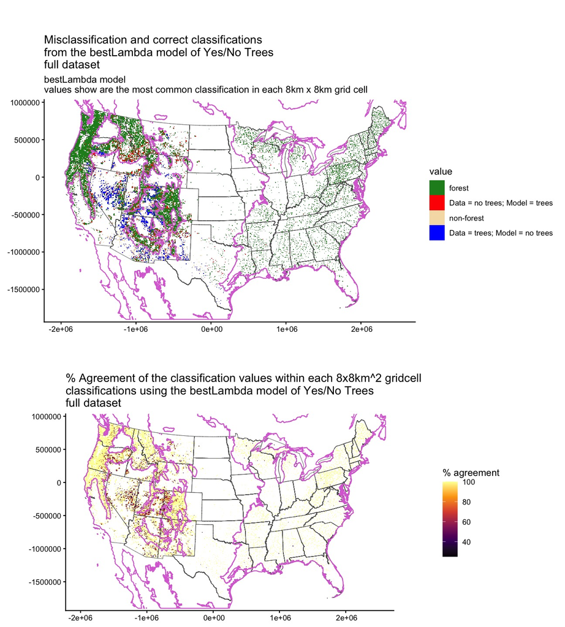

```r
# true positive = tree (1) (forest green)
# true negative = no tree (3) (wheat)
# false positive = model says tree, data says no-tree (2) (red)
# false negative = model says no tree, data says tree (4) (blue)
# make figures
map_missClass <- ggplot() +
geom_spatraster(data =pred_glm1_full_RAST
                , aes(fill= missClass), maxcell = 20000000) +
    #stat_summary_2d(data = pred_glm1, aes(x = x, y = y, z = missClass), fun = function(x) {round(mean(x))}, binwidth = .05) +
  geom_sf(data=cropped_states_2,fill=NA )  +
  geom_sf(data = mapRegions, fill = NA, col = "orchid", lwd = .5) +
  #geom_sf(data = badResids_high, col = "blue") +
  #geom_sf(data = badResids_low, col = "red") +
labs(title = paste0("Misclassification and correct classifications \nfrom the bestLambda model of Yes/No Trees \nfull dataset"),
     subtitle = "bestLambda model \nvalues show are the most common classification in each 8km x 8km grid cell") +
    scale_fill_discrete(palette =
                        c("forestgreen", "red", "wheat", "blue"),
                        na.value = "white",
                        labels = c("forest", "Data = no trees; Model = trees", "non-forest", "Data = trees; Model = no trees", "")) +
  coord_sf(datum = st_crs(pred_glm1_full_RAST)) +
  xlim(-2000000, 2500000) +
  ylim(-1800000, 900000)
# make a map of the aggreement in classification w/in each 8x8km cell
map_missClass_ag <- ggplot() +
  geom_spatraster(data = pred_glm1_full_RAST, aes(fill= PercAgreement), maxcell = 20000000) +
    #stat_summary_2d(data = pred_glm1, aes(x = x, y = y, z = missClass), fun = function(x) {round(mean(x))}, binwidth = .05) +
  geom_sf(data=cropped_states_2,fill=NA )  +
  geom_sf(data = mapRegions, fill = NA, col = "orchid", lwd = .5) +
  #geom_sf(data = badResids_high, col = "blue") +
  #geom_sf(data = badResids_low, col = "red") +
labs(title = paste0("% Agreement of the classification values within each 8x8km^2 gridcell \nclassifications using the bestLambda model of Yes/No Trees \nfull dataset"))+
    scale_fill_viridis_c(option = "B", na.value = "white", name = "% agreement", ) +
  coord_sf(datum = st_crs(pred_glm1_full_RAST)) +
  xlim(-2000000, 2500000) +
  ylim(-1800000, 900000)

ggarrange(map_missClass, map_missClass_ag, ncol = 1, heights = c(1, .7), align = "v")
```

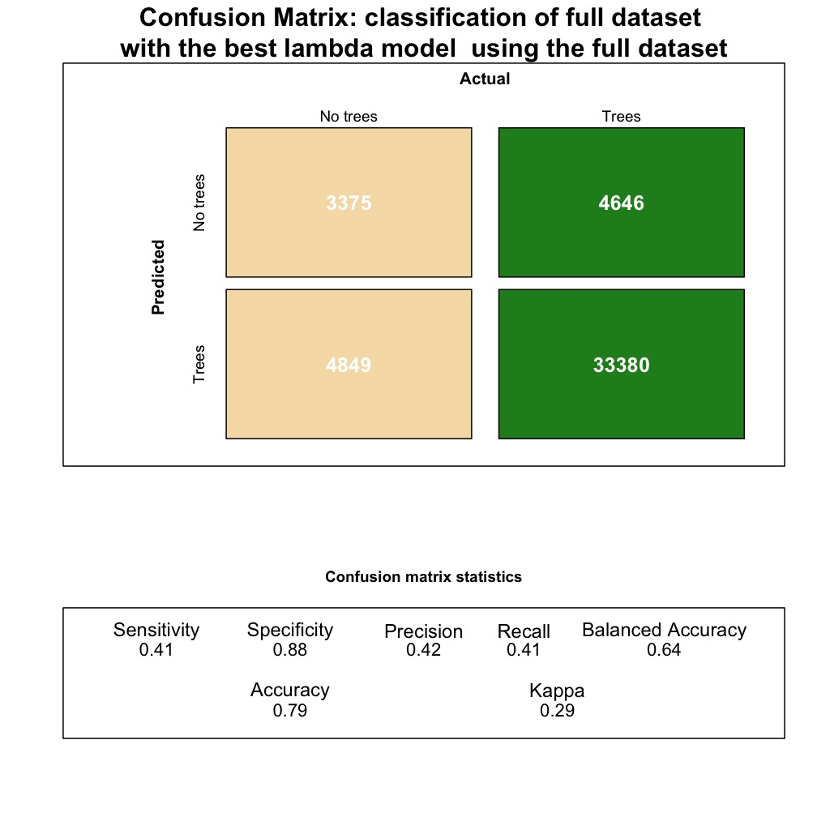

```r
# make a confusion matrix
# prepare data
matData <- pred_glm1_full %>%
  mutate(predClass = TotalTreeCover_binom_pred_binary,
         obsClass = TotalTreeCover_binom) %>%
  mutate(predClass = replace(predClass, predClass == 0, "no trees"),
         predClass = replace(predClass, predClass == 1, "trees"),
         obsClass = replace(obsClass, obsClass == 0, "no trees"),
         obsClass = replace(obsClass, obsClass == 1, "trees")) %>%
mutate(predClass = as.factor(predClass) ,
       obsClass = as.factor(obsClass))

# make matrix as a data.frame
# confMat <-  confusionMatrix(data = matData$predClass,
#                  reference = matData$obsClass)
ConfusionTableR::binary_visualiseR(
  train_labels = as.factor(matData$predClass),
  truth_labels = as.factor(matData$obsClass),
   class_label1 = "No trees",
   class_label2 = "Trees",
   quadrant_col1 = "wheat",
   quadrant_col2 = "forestgreen",
  text_col = "white", custom_title = "Confusion Matrix: classification of full dataset \nwith the best lambda model  using the full dataset"
)
```

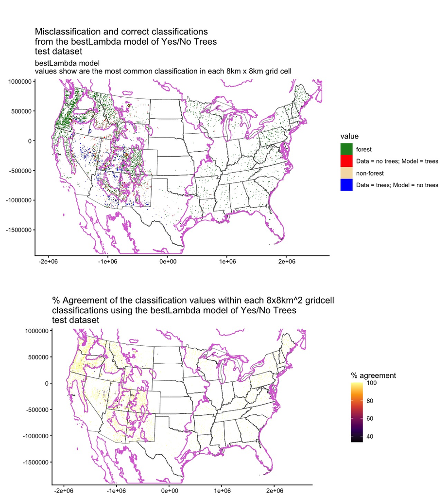

```r
### test dataset

# make figures
map_missClass_test <- ggplot() +
geom_spatraster(data =pred_glm1_test_RAST, aes(fill= missClass), maxcell = 20000000) +
    #stat_summary_2d(data = pred_glm1, aes(x = x, y = y, z = missClass), fun = function(x) {round(mean(x))}, binwidth = .05) +
  geom_sf(data=cropped_states_2,fill=NA )  +
  geom_sf(data = mapRegions, fill = NA, col = "orchid", lwd = .5) +
  #geom_sf(data = badResids_high, col = "blue") +
  #geom_sf(data = badResids_low, col = "red") +
labs(title = paste0("Misclassification and correct classifications \nfrom the bestLambda model of Yes/No Trees \ntest dataset"),
     subtitle = "bestLambda model \nvalues show are the most common classification in each 8km x 8km grid cell") +
    scale_fill_discrete(palette =
                        c("forestgreen", "red", "wheat", "blue"),
                        na.value = "white",
                        labels = c("forest", "Data = no trees; Model = trees", "non-forest", "Data = trees; Model = no trees", "")) +
  coord_sf(datum = st_crs(pred_glm1_full_RAST)) +
  xlim(-2000000, 2500000) +
  ylim(-1800000, 900000)
map_missClass_test_ag <- ggplot() +
  geom_spatraster(data = pred_glm1_test_RAST, aes(fill= PercAgreement), maxcell = 20000000) +
    #stat_summary_2d(data = pred_glm1, aes(x = x, y = y, z = missClass), fun = function(x) {round(mean(x))}, binwidth = .05) +
  geom_sf(data=cropped_states_2,fill=NA )  +
  geom_sf(data = mapRegions, fill = NA, col = "orchid", lwd = .5) +
  #geom_sf(data = badResids_high, col = "blue") +
  #geom_sf(data = badResids_low, col = "red") +
labs(title = paste0("% Agreement of the classification values within each 8x8km^2 gridcell \nclassifications using the bestLambda model of Yes/No Trees \ntest dataset"))+
    scale_fill_viridis_c(option = "B", na.value = "white", name = "% agreement", ) +
  coord_sf(datum = st_crs(pred_glm1_full_RAST)) +
  xlim(-2000000, 2500000) +
  ylim(-1800000, 900000)


  ggarrange(map_missClass_test, map_missClass_test_ag, ncol = 1, heights = c(1, .7), align = "v")
```

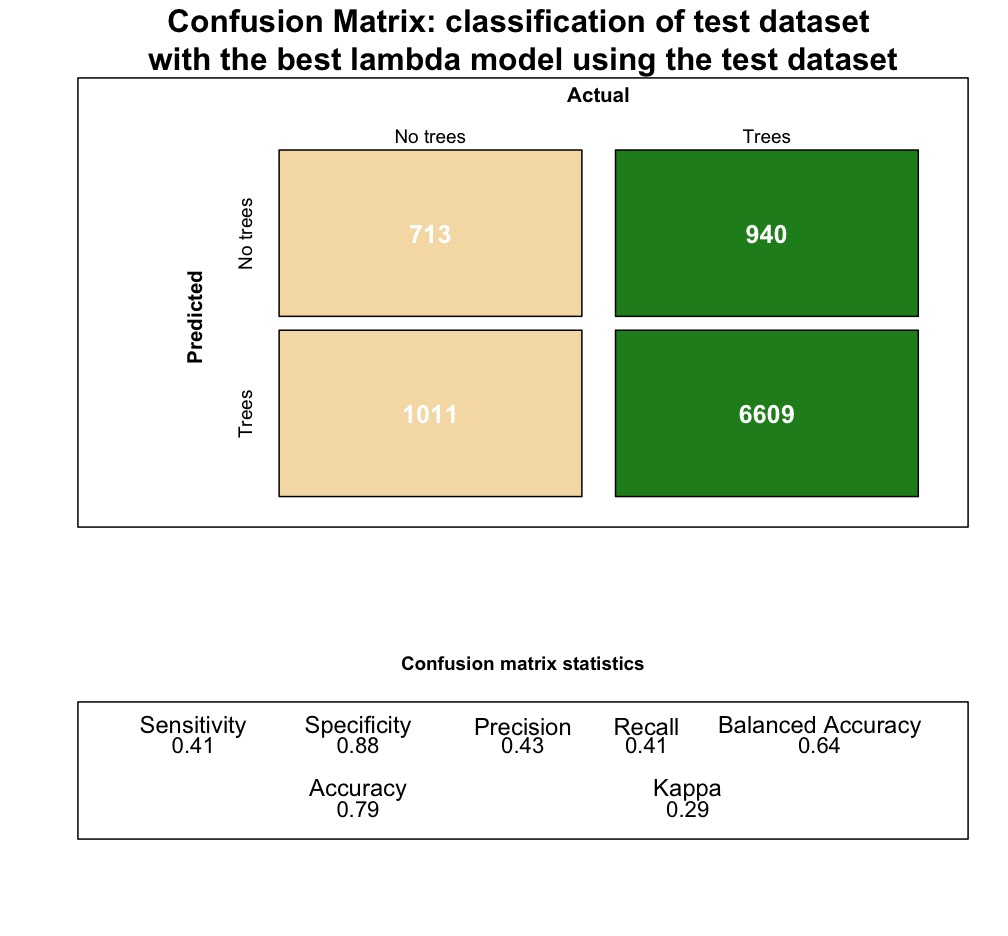

```r
# make a confusion matrix
# prepare data
matData_test <- pred_glm1_test %>%
  mutate(predClass = TotalTreeCover_binom_pred_binary,
         obsClass = TotalTreeCover_binom) %>%
  mutate(predClass = replace(predClass, predClass == 0, "no trees"),
         predClass = replace(predClass, predClass == 1, "trees"),
         obsClass = replace(obsClass, obsClass == 0, "no trees"),
         obsClass = replace(obsClass, obsClass == 1, "trees")) %>%
mutate(predClass = as.factor(predClass) ,
       obsClass = as.factor(obsClass))

# make matrix as a data.frame
# confMat <-  confusionMatrix(data = matData$predClass,
#                  reference = matData$obsClass)
ConfusionTableR::binary_visualiseR(
  train_labels = as.factor(matData_test$predClass),
  truth_labels = as.factor(matData_test$obsClass),
   class_label1 = "No trees",
   class_label2 = "Trees",
   quadrant_col1 = "wheat",
   quadrant_col2 = "forestgreen",
  text_col = "white", custom_title = "Confusion Matrix: classification of test dataset \nwith the best lambda model using the test dataset"
)
```

### A map of classification error of predictions on the full and test datasets made using the *second best lambda model*

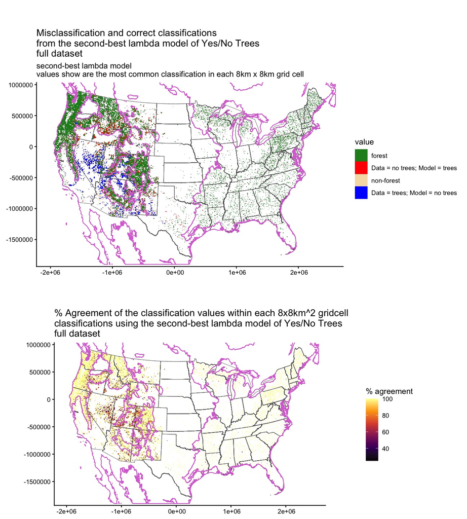

```r
### full dataset
# make figures
map_missClass <- ggplot() +
geom_spatraster(data =pred_glm1_1se_full_RAST, aes(fill= missClass), maxcell = 20000000) +
    #stat_summary_2d(data = pred_glm1, aes(x = x, y = y, z = missClass), fun = function(x) {round(mean(x))}, binwidth = .05) +
  geom_sf(data=cropped_states_2,fill=NA )  +
  geom_sf(data = mapRegions, fill = NA, col = "orchid", lwd = .5) +
  #geom_sf(data = badResids_high, col = "blue") +
  #geom_sf(data = badResids_low, col = "red") +
labs(title = paste0("Misclassification and correct classifications \nfrom the second-best lambda model of Yes/No Trees \nfull dataset"),
     subtitle = "second-best lambda model \nvalues show are the most common classification in each 8km x 8km grid cell") +
  scale_fill_discrete(palette =
                        c("forestgreen", "red", "wheat", "blue"),
                        na.value = "white",
                        labels = c("forest", "Data = no trees; Model = trees", "non-forest", "Data = trees; Model = no trees", "")) +
  coord_sf(datum = st_crs(pred_glm1_full_RAST)) +
  xlim(-2000000, 2500000) +
  ylim(-1800000, 900000)
map_missClass_ag <- ggplot() +
  geom_spatraster(data = pred_glm1_1se_full_RAST, aes(fill= PercAgreement), maxcell = 20000000) +
    #stat_summary_2d(data = pred_glm1, aes(x = x, y = y, z = missClass), fun = function(x) {round(mean(x))}, binwidth = .05) +
  geom_sf(data=cropped_states_2,fill=NA )  +
  geom_sf(data = mapRegions, fill = NA, col = "orchid", lwd = .5) +
  #geom_sf(data = badResids_high, col = "blue") +
  #geom_sf(data = badResids_low, col = "red") +
labs(title = paste0("% Agreement of the classification values within each 8x8km^2 gridcell \nclassifications using the second-best lambda model of Yes/No Trees \nfull dataset"))+
    scale_fill_viridis_c(option = "B", na.value = "white", name = "% agreement", ) +
  coord_sf(datum = st_crs(pred_glm1_full_RAST)) +
  xlim(-2000000, 2500000) +
  ylim(-1800000, 900000)

ggarrange(map_missClass, map_missClass_ag, ncol = 1, heights = c(1, .7), align = "v")
```

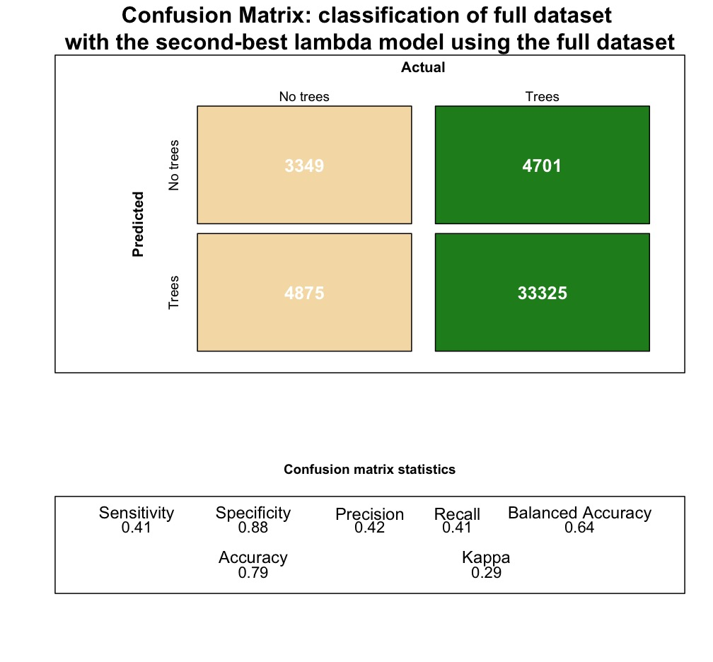

```r
# make a confusion matrix
# prepare data
matData <- pred_glm1_1se_full %>%
  mutate(predClass = TotalTreeCover_binom_pred_binary,
         obsClass = TotalTreeCover_binom) %>%
  mutate(predClass = replace(predClass, predClass == 0, "no trees"),
         predClass = replace(predClass, predClass == 1, "trees"),
         obsClass = replace(obsClass, obsClass == 0, "no trees"),
         obsClass = replace(obsClass, obsClass == 1, "trees")) %>%
mutate(predClass = as.factor(predClass) ,
       obsClass = as.factor(obsClass))

# make matrix as a data.frame
# confMat <-  confusionMatrix(data = matData$predClass,
#                  reference = matData$obsClass)
ConfusionTableR::binary_visualiseR(
  train_labels = as.factor(matData$predClass),
  truth_labels = as.factor(matData$obsClass),
   class_label1 = "No trees",
   class_label2 = "Trees",
   quadrant_col1 = "wheat",
   quadrant_col2 = "forestgreen",
  text_col = "white", custom_title = "Confusion Matrix: classification of full dataset \nwith the second-best lambda model using the full dataset"
)
```

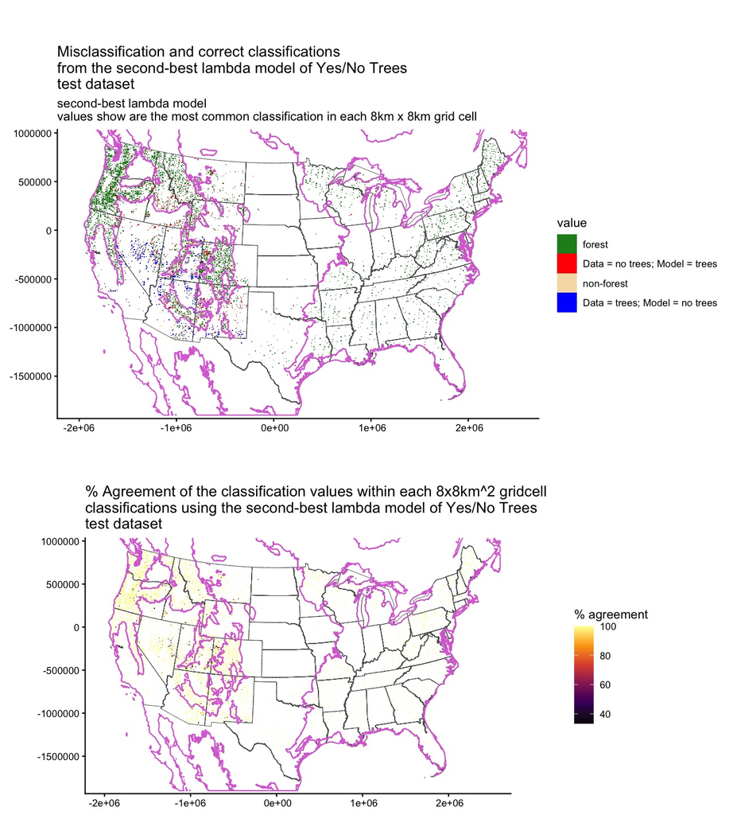

```r
### test dataset
# make figures
map_missClass_test <- ggplot() +
geom_spatraster(data =pred_glm1_1se_test_RAST, aes(fill= missClass), maxcell = 20000000) +
    #stat_summary_2d(data = pred_glm1, aes(x = x, y = y, z = missClass), fun = function(x) {round(mean(x))}, binwidth = .05) +
  geom_sf(data=cropped_states_2,fill=NA )  +
  geom_sf(data = mapRegions, fill = NA, col = "orchid", lwd = .5) +
  #geom_sf(data = badResids_high, col = "blue") +
  #geom_sf(data = badResids_low, col = "red") +
labs(title = paste0("Misclassification and correct classifications \nfrom the second-best lambda model of Yes/No Trees \ntest dataset"),
     subtitle = "second-best lambda model \nvalues show are the most common classification in each 8km x 8km grid cell") +
     scale_fill_discrete(palette =
                        c("forestgreen", "red", "wheat", "blue"),
                        na.value = "white",
                        labels = c("forest", "Data = no trees; Model = trees", "non-forest", "Data = trees; Model = no trees", "")) +
  coord_sf(datum = st_crs(pred_glm1_full_RAST)) +
  xlim(-2000000, 2500000) +
  ylim(-1800000, 900000)

map_missClass_test_ag <- ggplot() +
  geom_spatraster(data = pred_glm1_1se_test_RAST, aes(fill= PercAgreement), maxcell = 20000000) +
    #stat_summary_2d(data = pred_glm1, aes(x = x, y = y, z = missClass), fun = function(x) {round(mean(x))}, binwidth = .05) +
  geom_sf(data=cropped_states_2,fill=NA )  +
  geom_sf(data = mapRegions, fill = NA, col = "orchid", lwd = .5) +
  #geom_sf(data = badResids_high, col = "blue") +
  #geom_sf(data = badResids_low, col = "red") +
labs(title = paste0("% Agreement of the classification values within each 8x8km^2 gridcell \nclassifications using the second-best lambda model of Yes/No Trees \ntest dataset"))+
    scale_fill_viridis_c(option = "B", na.value = "white", name = "% agreement", ) +
  coord_sf(datum = st_crs(pred_glm1_full_RAST)) +
  xlim(-2000000, 2500000) +
  ylim(-1800000, 900000)

  ggarrange(map_missClass_test, map_missClass_test_ag, ncol = 1, heights = c(1, .7), align = "v")
```

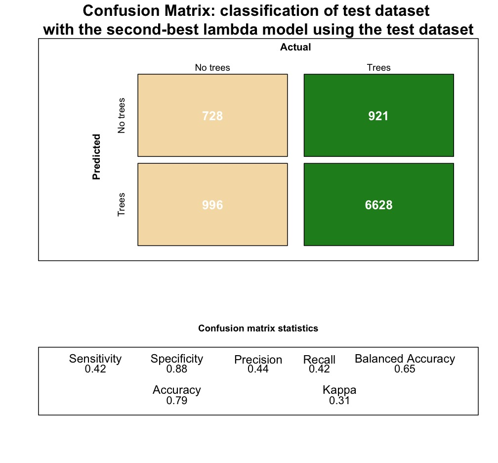

```r
# make a confusion matrix
# prepare data
matData_test <- pred_glm1_1se_test %>%
  mutate(predClass = TotalTreeCover_binom_pred_binary,
         obsClass = TotalTreeCover_binom) %>%
  mutate(predClass = replace(predClass, predClass == 0, "no trees"),
         predClass = replace(predClass, predClass == 1, "trees"),
         obsClass = replace(obsClass, obsClass == 0, "no trees"),
         obsClass = replace(obsClass, obsClass == 1, "trees")) %>%
mutate(predClass = as.factor(predClass) ,
       obsClass = as.factor(obsClass))

# make matrix as a data.frame
# confMat <-  confusionMatrix(data = matData$predClass,
#                  reference = matData$obsClass)
ConfusionTableR::binary_visualiseR(
  train_labels = as.factor(matData_test$predClass),
  truth_labels = as.factor(matData_test$obsClass),
   class_label1 = "No trees",
   class_label2 = "Trees",
   quadrant_col1 = "wheat",
   quadrant_col2 = "forestgreen",
  text_col = "white", custom_title = "Confusion Matrix: classification of test dataset \nwith the second-best lambda model using the test dataset"
)
```

### Are there biases of the model predictions across year/lat/long? (for the full dataset)

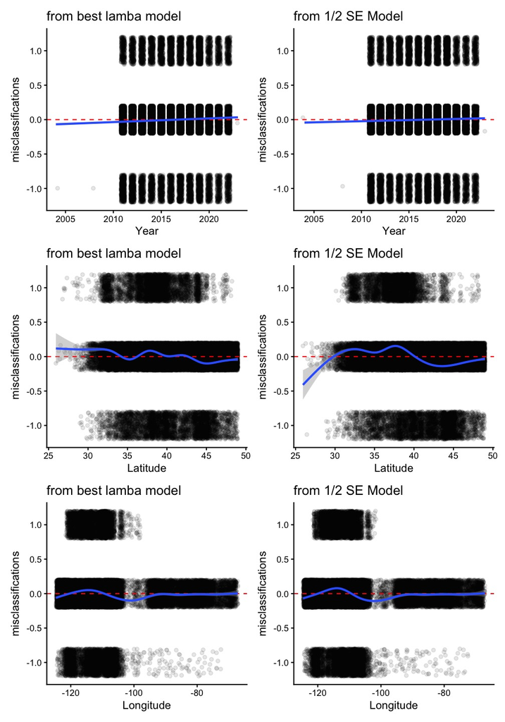

```r
if ( name_secondBestMod == "Intercept_Only") {
  print("The next best lambda model only contains one predictor (an intercept)")

  ## calculate Misclassification in the input pred_glm1 or pred_glm1se datasets
  pred_glm1_full$missClass2 <- pred_glm1_full$TotalTreeCover_binom - pred_glm1_full$TotalTreeCover_binom_pred_binary
  pred_glm1_test$missClass2 <- pred_glm1_test$TotalTreeCover_binom - pred_glm1_test$TotalTreeCover_binom_pred_binary

  # plot misclassifications against Year
yearResidMod_bestLambda <- ggplot(pred_glm1_full) +
  geom_point(aes(x = jitter(Year), y = jitter(missClass2)), alpha = .1) +
  geom_hline(aes(yintercept = 0), lty = 2, col = "red") +
  geom_smooth(aes(x = Year, y = missClass2), method = "lm") +
  xlab("Year") +
  ylab("misclassifications") +
  ggtitle("from best lamba model")

# plot misclassifications against Lat
latResidMod_bestLambda <- ggplot(pred_glm1_full) +
  geom_point(aes(x = y, y = jitter(missClass2)), alpha = .1) +
  geom_hline(aes(yintercept = 0), lty = 2, col = "red") +
  geom_smooth(aes(x = y, y = missClass2)) +
  xlab("Latitude") +
  ylab("misclassifications") +
  ggtitle("from best lamba model")

# plot misclassifications against Long
longResidMod_bestLambda <- ggplot(pred_glm1_full) +
  geom_point(aes(x = x, y = jitter(missClass2)), alpha = .1) +
  geom_hline(aes(yintercept = 0), lty = 2, col = "red") +
  geom_smooth(aes(x = x, y = missClass2)) +
  xlab("Longitude") +
  ylab("misclassifications") +
  ggtitle("from best lamba model")
library(patchwork)
(yearResidMod_bestLambda ) /
(  latResidMod_bestLambda ) /
(  longResidMod_bestLambda )
} else {

  ## calculate missClass2ification in the input pred_glm1 or pred_glm1se datasets
  pred_glm1_full$missClass2 <- pred_glm1_full$TotalTreeCover_binom - pred_glm1_full$TotalTreeCover_binom_pred_binary
  pred_glm1_test$missClass2 <- pred_glm1_test$TotalTreeCover_binom - pred_glm1_test$TotalTreeCover_binom_pred_binary
  pred_glm1_1se_full$missClass2 <- pred_glm1_1se_full$TotalTreeCover_binom - pred_glm1_1se_full$TotalTreeCover_binom_pred_binary
  pred_glm1_1se_test$missClass2 <- pred_glm1_1se_test$TotalTreeCover_binom - pred_glm1_1se_test$TotalTreeCover_binom_pred_binary

# plot misclassifications against Year
yearResidMod_bestLambda <- ggplot(pred_glm1_full) +
  geom_point(aes(x = jitter(Year), y = jitter(missClass2)), alpha = .1) +
  geom_hline(aes(yintercept = 0), lty = 2, col = "red") +
  geom_smooth(aes(x = Year, y = missClass2), method = "lm") +
  xlab("Year") +
  ylab("misclassifications") +
  ggtitle("from best lamba model")
yearResidMod_1seLambda <- ggplot(pred_glm1_1se_full) +
  geom_point(aes(x = jitter(Year), y = jitter(missClass2)), alpha = .1) +
  geom_hline(aes(yintercept = 0), lty = 2, col = "red") +
  geom_smooth(aes(x = Year, y = missClass2), method = "lm") +
  xlab("Year") +
  ylab("misclassifications") +
  ggtitle(paste0("from ", name_secondBestMod))

# plot misclassifications against Lat
latResidMod_bestLambda <- ggplot(pred_glm1_full) +
  geom_point(aes(x = y, y = jitter(missClass2)), alpha = .1) +
  geom_hline(aes(yintercept = 0), lty = 2, col = "red") +
  geom_smooth(aes(x = y, y = missClass2)) +
  xlab("Latitude") +
  ylab("misclassifications") +
  ggtitle("from best lamba model")
latResidMod_1seLambda <- ggplot(pred_glm1_1se_full) +
  geom_point(aes(x = y, y = jitter(missClass2)), alpha = .1) +
  geom_hline(aes(yintercept = 0), lty = 2, col = "red") +
  geom_smooth(aes(x = y, y = missClass2)) +
  xlab("Latitude") +
  ylab("misclassifications") +
  ggtitle(paste0("from ", name_secondBestMod))

# plot misclassifications against Long
longResidMod_bestLambda <- ggplot(pred_glm1_full) +
  geom_point(aes(x = x, y = jitter(missClass2)), alpha = .1) +
  geom_hline(aes(yintercept = 0), lty = 2, col = "red") +
  geom_smooth(aes(x = x, y = missClass2)) +
  xlab("Longitude") +
  ylab("misclassifications") +
  ggtitle("from best lamba model")
longResidMod_1seLambda <- ggplot(pred_glm1_1se_full) +
  geom_point(aes(x = x, y = jitter(missClass2)), alpha = .1) +
  geom_hline(aes(yintercept = 0), lty = 2, col = "red") +
  geom_smooth(aes(x = x, y = missClass2)) +
  xlab("Longitude") +
  ylab("misclassifications") +
  ggtitle(paste0("from ", name_secondBestMod))

library(patchwork)
(yearResidMod_bestLambda + yearResidMod_1seLambda) /
(  latResidMod_bestLambda + latResidMod_1seLambda) /
(  longResidMod_bestLambda + longResidMod_1seLambda)
}
```

### Quantile plots - comparing “binary” observations across the full dataset to continuous model-predicted probabilities

Binning predictor variables into “Quantiles”and looking at the mean predicted probability for each quantile

```r
response_vars <- c("TotalTreeCover_binom", "TotalTreeCover_binom_pred")
# get deciles for best lambda model
if (length(prednames_fig) == 0) {
  print("The best lambda model only contains one predictor (an intercept), so decile plots aren't possible to generate")
} else {
  pred_glm1_deciles <- predvars2deciles(pred_glm1_full,
                                      response_vars = response_vars,
                                        pred_vars = prednames_fig,
                                       cut_points = seq(0, 1, 0.01))
}
# get deciles for 1 SE lambda model
if ( name_secondBestMod == "Intercept_Only") {
  print("The next best lambda model only contains one predictor (an intercept)")} else {
  pred_glm1_deciles_1se <- predvars2deciles(pred_glm1_1se_full,
                                      response_vars = response_vars,
                                        pred_vars = prednames_secondBestMod,
                                       cut_points = seq(0, 1, 0.01))
  }
```

Below are quantile plots for the *best lambda model* (note that the predictor variables are scaled)

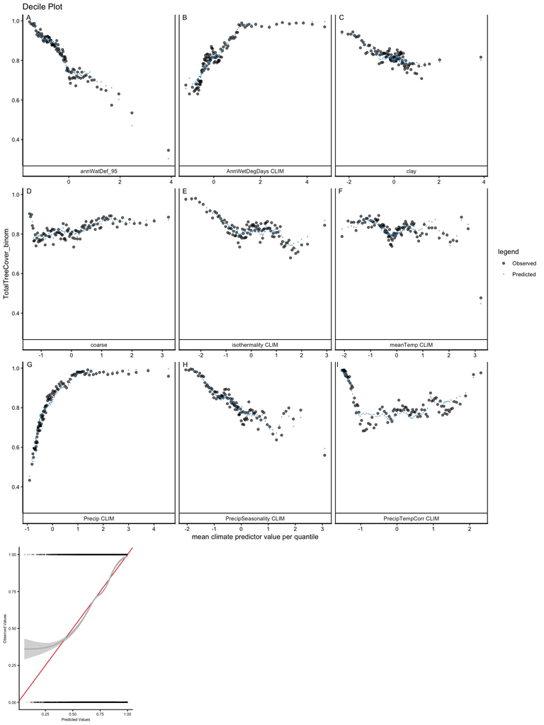

```r
if (length(prednames_fig) == 0) {
  print("The model only contains one predictor (an intercept), so decile plots aren't possible to generate")
} else {

# publication quality version
g3 <- decile_dotplot_pq(df = pred_glm1_deciles, response = c("TotalTreeCover_binom", paste0("TotalTreeCover_binom", "_pred")), IQR = FALSE,
                        CI = FALSE
                        ) + ggtitle("Decile Plot")

g4 <- add_dotplot_inset(g3, df = pred_glm1_deciles, response = c("TotalTreeCover_binom", paste0("TotalTreeCover_binom", "_pred")), dfRaw = pred_glm1_full, add_smooth = TRUE, deciles = FALSE)


if(save_figs) {
  # png(paste0("../../../Figures/CoverDatFigures/ figures/quantile_plots/quantile_plot_", response,  "_",ecoregion,".png"),
  #    units = "in", res = 600, width = 5.5, height = 3.5 )
  #   print(g4)
  # dev.off()
}

g4
}
```

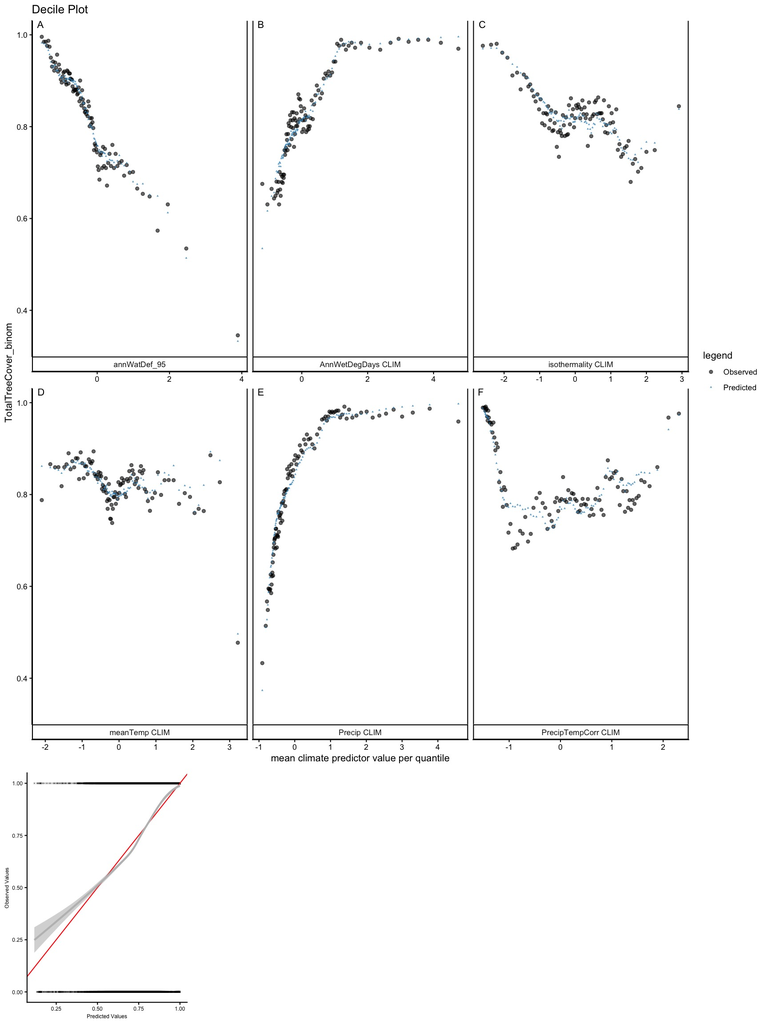

```r
if ( name_secondBestMod == "Intercept_Only") {
  print("The next best lambda model only contains one predictor (an intercept)")
  } else {

# publication quality version
g3 <- decile_dotplot_pq(pred_glm1_deciles_1se, response = c("TotalTreeCover_binom", paste0("TotalTreeCover_binom", "_pred")), IQR = FALSE) + ggtitle("Decile Plot")

g4 <- add_dotplot_inset(g3, df = pred_glm1_deciles_1se, response = c("TotalTreeCover_binom", paste0("TotalTreeCover_binom", "_pred")), dfRaw = pred_glm1_1se_full, add_smooth = TRUE, deciles = FALSE)


if(save_figs) {
  # png(paste0("figures/quantile_plots/quantile_plot_", response,  "_",ecoregion,".png"),
  #    units = "in", res = 600, width = 5.5, height = 3.5 )
  #   print(g4)
  # dev.off()
}

g4
}
```

#### For the best lambda model

Filtered quantile plots of data. These plots show each vegetation variable, but only based on data that falls into the upper and lower 20th percentiles of each predictor variable.

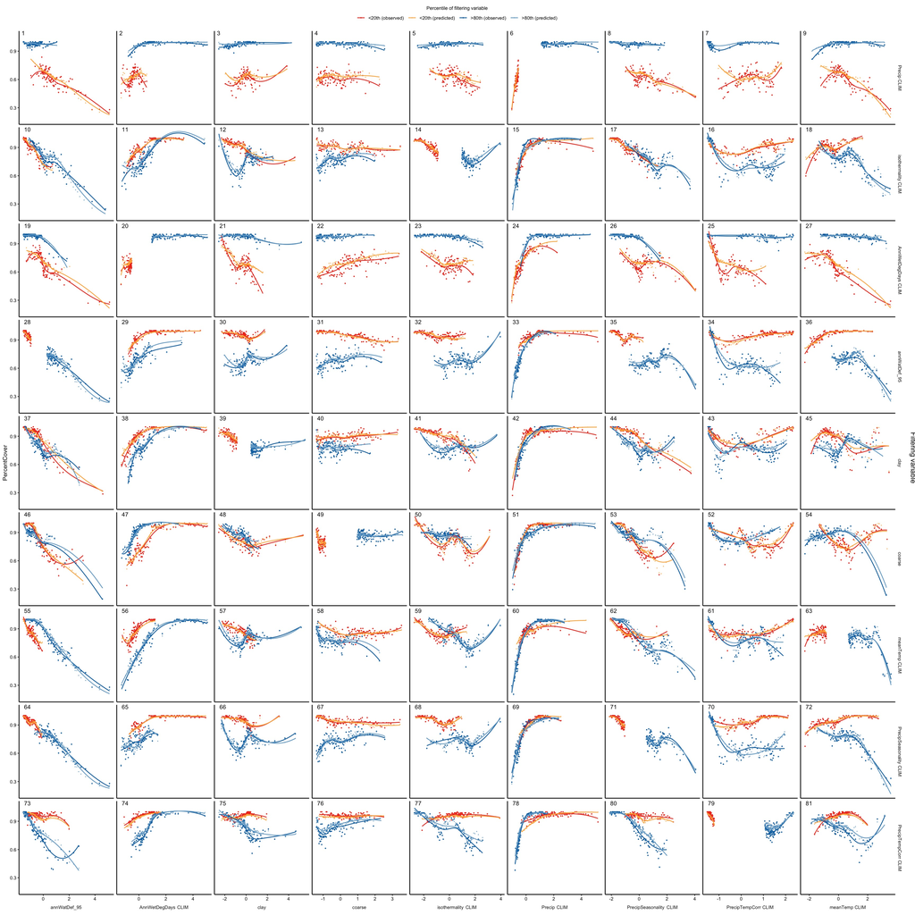

```r
if (length(prednames_fig) == 0) {
  print("The model only contains one predictor (an intercept), so decile plots aren't possible to generate")
} else {
pred_glm1_deciles_filt <- predvars2deciles( pred_glm1_full,
                         response_vars = c("TotalTreeCover_binom", paste0("TotalTreeCover_binom", "_pred")),
                         pred_vars = prednames_fig,
                         filter_var = TRUE,
                         filter_vars = prednames_fig,
                         cut_points = seq(0, 1, 0.01))
g <- decile_dotplot_filtered_pq(df = pred_glm1_deciles_filt, response = "TotalTreeCover_binom",
                                xvars = prednames_fig)

if(save_figs) {
# jpeg(paste0("figures/quantile_plots/quantile_plot_filtered_mid_v1", , ".jpeg"),
#      units = "in", res = 600, width = 5.5, height = 6 )
#   g
# dev.off()
}
g
}
```

Filtered quantile figure with middle 2 deciles also shown

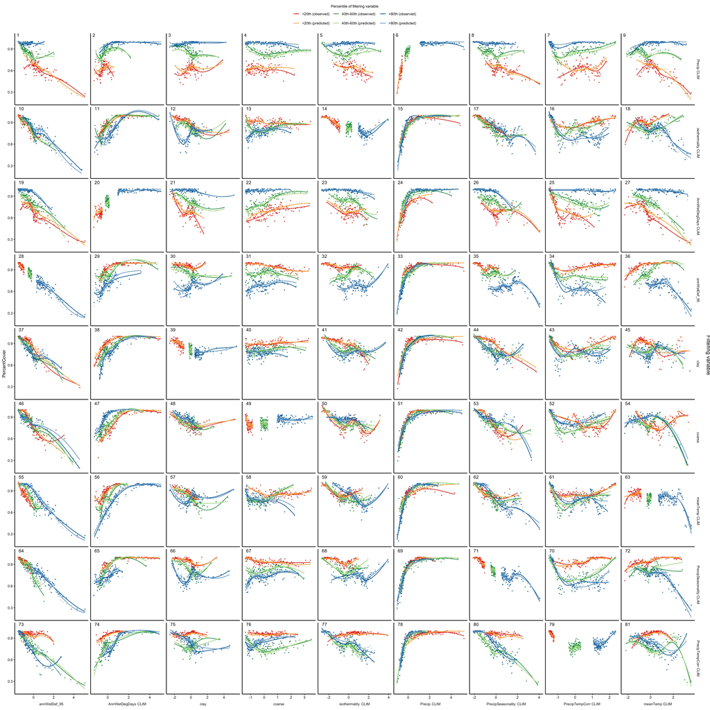

```r
if ( name_secondBestMod == "Intercept_Only") {
  print("The next best lambda model only contains one predictor (an intercept)")
} else {
pred_glm1_deciles_filt_mid <- predvars2deciles(pred_glm1_full,
                         response_vars = c("TotalTreeCover_binom", paste0("TotalTreeCover_binom", "_pred")),
                         pred_vars = prednames_fig,
                         filter_vars = prednames_fig,
                         filter_var = TRUE,
                         add_mid = TRUE,
                         cut_points = seq(0, 1, 0.01))

g <- decile_dotplot_filtered_pq(df = pred_glm1_deciles_filt_mid, response = "TotalTreeCover_binom",
                                xvars = prednames_fig)

if(save_figs) {
# jpeg(paste0("figures/quantile_plots/quantile_plot_filtered_mid_v1", , ".jpeg"),
#      units = "in", res = 600, width = 5.5, height = 6)
#   g
# dev.off()
}
g
}
```

Filtered ‘Quantile’ plots of data. These plots show each vegetation variable, but only based on data that falls into the upper and lower 20th percentiles of each predictor variable.

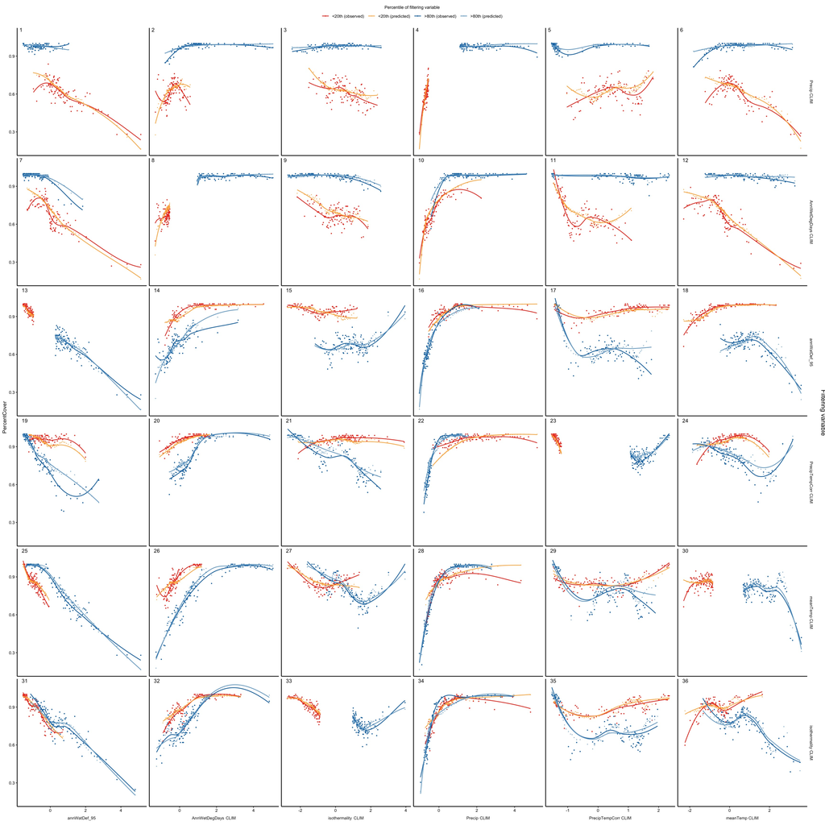

```r
if (length(prednames_secondBestMod) == 0) {
  print("The model only contains one predictor (an intercept), so decile plots aren't possible to generate")
} else {

pred_glm1_deciles_filt <- predvars2deciles( pred_glm1_1se_full,
                         response_vars = c("TotalTreeCover_binom", paste0("TotalTreeCover_binom", "_pred")),
                         pred_vars = prednames_secondBestMod,
                         filter_var = TRUE,
                         filter_vars = prednames_secondBestMod,
                         cut_points = seq(0, 1, 0.01))
g <- decile_dotplot_filtered_pq(df = pred_glm1_deciles_filt, response = "TotalTreeCover_binom",
                                xvars = prednames_fig)

if(save_figs) {
# jpeg(paste0("figures/quantile_plots/quantile_plot_filtered_mid_v1", , ".jpeg"),
#      units = "in", res = 600, width = 5.5, height = 6 )
#   g
# dev.off()
}
g
}
```

Filtered quantile figure with middle 2 deciles also shown

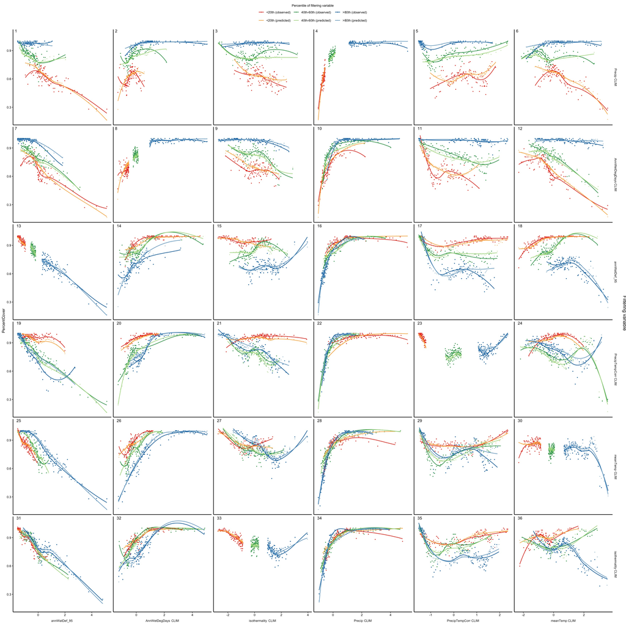

```r
if (length(prednames_secondBestMod) == 0) {
  print("The model only contains one predictor (an intercept), so decile plots aren't possible to generate")
} else {
pred_glm1_deciles_filt_mid <- predvars2deciles(pred_glm1_1se_full,
                         response_vars = c("TotalTreeCover_binom", paste0("TotalTreeCover_binom", "_pred")),
                         pred_vars = prednames_secondBestMod,
                         filter_vars = prednames_secondBestMod,
                         filter_var = TRUE,
                         add_mid = TRUE,
                         cut_points = seq(0, 1, 0.01))

g <- decile_dotplot_filtered_pq(df = pred_glm1_deciles_filt_mid, response = "TotalTreeCover_binom",
                                xvars = prednames_fig)


if(save_figs) {
# jpeg(paste0("figures/quantile_plots/quantile_plot_filtered_mid_v1", , ".jpeg"),
#      units = "in", res = 600, width = 5.5, height = 6 )
#   g
# dev.off()
}
g
}
```

```r
response_vars <- c("TotalTreeCover_binom", "TotalTreeCover_binom_pred_binary")
# get deciles for best lambda model
if (length(prednames_fig) == 0) {
  print("The best lambda model only contains one predictor (an intercept), so decile plots aren't possible to generate")
} else {
  pred_glm1_deciles <- predvars2deciles(pred_glm1_full,
                                      response_vars = response_vars,
                                        pred_vars = prednames_fig,
                                       cut_points = seq(0, 1, 0.01))
}
# get deciles for 1 SE lambda model
if ( name_secondBestMod == "Intercept_Only") {
  print("The next best lambda model only contains one predictor (an intercept)")} else {
  pred_glm1_deciles_1se <- predvars2deciles(pred_glm1_1se_full,
                                      response_vars = response_vars,
                                        pred_vars = prednames_secondBestMod,
                                       cut_points = seq(0, 1, 0.01))
  }
```

Below are quantile plots for the *best lambda model* (note that the predictor variables are scaled)

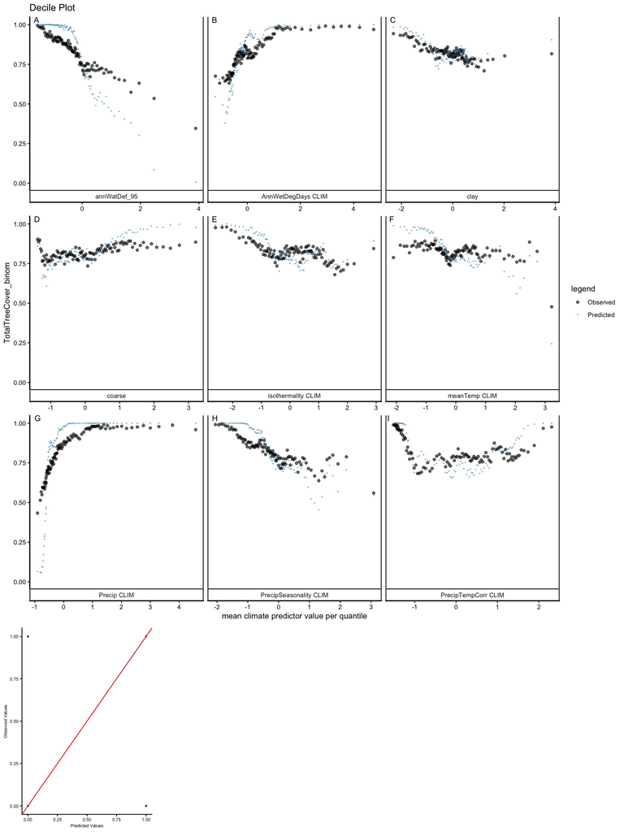

```r
if (length(prednames_fig) == 0) {
  print("The model only contains one predictor (an intercept), so decile plots aren't possible to generate")
} else {
# ####  code to generate plots analagous to "decile plots" by hand, do double check that they're suitable for use w/ binary predictions
#   pred_glm1 %>%
#     #slice_sample(n = 10000) %>%
#     pivot_longer(cols = all_of(prednames_fig)) %>%
#     select(Year, x, y, TotalTreeCover_binom, TotalTreeCover_binom_pred_binary, name, value) %>%
#     ggplot() +
#     facet_wrap(~name, scales = "free") +
#     geom_point(aes(x = value, y = jitter(TotalTreeCover_binom)), alpha = .5) +
#     geom_point(aes(x = value, y = jitter(TotalTreeCover_binom_pred_binary)), col = "blue", alpha = .5) +
#     geom_smooth(aes(x = value, y = TotalTreeCover_binom), col = "black") +
#     geom_smooth(aes(x = value, y = TotalTreeCover_binom_pred_binary), col = "blue")
#


  #####
# publication quality version
g3 <- decile_dotplot_pq(df = pred_glm1_deciles, response = c("TotalTreeCover_binom", paste0("TotalTreeCover_binom", "_pred_binary")), IQR = FALSE,
                        CI = FALSE
                        ) + ggtitle("Decile Plot")

g4 <- add_dotplot_inset(g3, df = pred_glm1_deciles, response = c("TotalTreeCover_binom", paste0("TotalTreeCover_binom", "_pred_binary")), dfRaw = pred_glm1_full, add_smooth = TRUE, deciles = FALSE)


if(save_figs) {
  # png(paste0("../../../Figures/CoverDatFigures/ figures/quantile_plots/quantile_plot_", response,  "_",ecoregion,".png"),
  #    units = "in", res = 600, width = 5.5, height = 3.5 )
  #   print(g4)
  # dev.off()
}

g4
}
```

Below are quantile plots from the second best lambda model (not that the predictor variables are scaled)

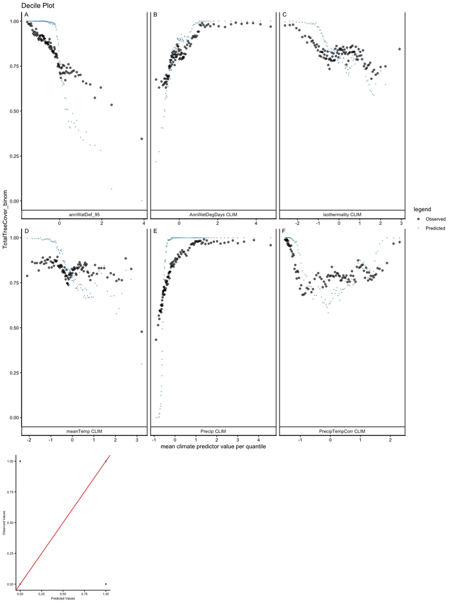

```r
if ( name_secondBestMod == "Intercept_Only") {
  print("The next best lambda model only contains one predictor (an intercept)")
  } else {

# publication quality version
g3 <- decile_dotplot_pq(pred_glm1_deciles_1se, response = c("TotalTreeCover_binom", paste0("TotalTreeCover_binom", "_pred_binary")), IQR = FALSE) + ggtitle("Decile Plot")

g4 <- add_dotplot_inset(g3, df = pred_glm1_deciles_1se, response = c("TotalTreeCover_binom", paste0("TotalTreeCover_binom", "_pred_binary")), dfRaw = pred_glm1_1se_full, add_smooth = TRUE, deciles = FALSE)


if(save_figs) {
  # png(paste0("figures/quantile_plots/quantile_plot_", response,  "_",ecoregion,".png"),
  #    units = "in", res = 600, width = 5.5, height = 3.5 )
  #   print(g4)
  # dev.off()
}

g4
}
```